# DADA2 Metabarcoding Workflow

Luke E. Holman

2019-06-24

Many contempory metabarcoding workflows ignore qualty information provided by Illumnia sequencing and in doing so lose the ability to accurately determine lowe frequency sequence diversity.

DADA2 is an approach (paper [here](https://benjjneb.github.io/dada2/index.html)) gaining popularity that integrates the quality information to build an model of sequence errors that allowing for very precise inference of amplicon sequences. Here, we show how DADA2 can be implimented in the metabarTOAD wrapper.

### Requirements

#### Library design

This tutorial is designed for paired-end Illumina amplicon data generated from a 2-step PCR method as [Bista et al.2017](https://www.nature.com/articles/ncomms14087). We are expecting sufficient (>30bp) overlap of the paired end reads. DADA2 learns and performs amplicon inference according to the error model, specific to each Illumina run so samples from different runs should be analysed seperately. This tutorial is designed to analyse data from a single primer set at a time.

#### Software

For this tutorial you will need the following

- Cutadapt (version 2.0+) [link](https://cutadapt.readthedocs.io/en/stable/installation.html)
- DADA2 (version 1.8+) [link](https://benjjneb.github.io/dada2/dada-installation.html)

Cutadapt should be installed and working on your system. Keep a note of the directory path to the binary or have them in your PATH. Not sure about the PATH? - go [here](http://www.linfo.org/path_env_var.html)

## Workflow Overview

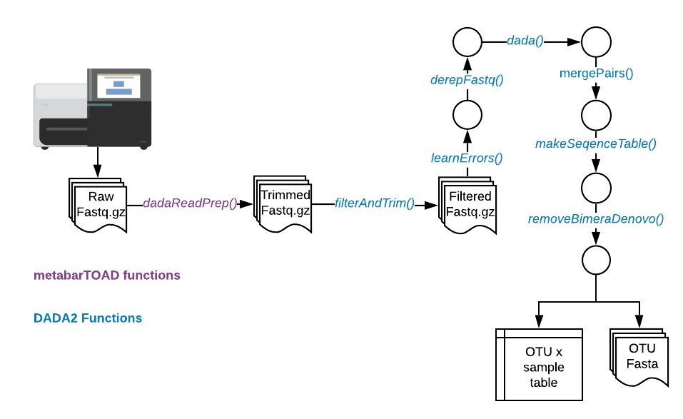

## Setting up

Make sure you start off with a clean folder in a new working directory. Check there is nothing in your directory with `dir()`. Lets start by loading up the required package(s)

```r
require(metabarTOAD)
require(dada2)
```

If you previously used the metabarTOAD workflow to generate 97% OTUs or denoised OTUs with UNOISE3 then the correct folder structure is already in place. Otherwise use the below command to set up some folders for the analysis.

```r
Folders()
```

Now we have a folder structure lets move our raw Illumina data into the `1.rawreads`. You might wish to copy your raw files into the `0.backup` folder as well in case you want to start the analysis again from scratch.